# Neural Correlates of Decision Making: Analyzing Visual Cortex Activity in Mice during Stimulus Discrimination Trials

By Seongeun Jeon

March 18, 2024

*This report obeys the following contents:

### | 1. Introduction |

The study investigates the connection between decision-making and neural activity by analyzing the behavior of neurons in the visual cortex of mice during stimulus discrimination trials. According to the data provided by *Steinmetz et al. (2019)*, 18 sessions were conducted on four mice: Cori, Frossman, Hence, and Lederberg. The analysis also examines the response patterns of neurons from stimulus pre-onset to 0.4 seconds post-onset. During the sessions, the four mice were presented with various levels of visual stimuli that required them to make decisions using a forepaw-controlled wheel. Successful task performance resulted in rewards, while failure led to penalties. The primary objective of the analysis is to understand how neuronal firing patterns correlate with different task parameters, such as stimulus contrast and decision outcomes, to make a high success rating model in the later section of the report.

### | 2. Exploratory analysis |

Comprehending significant elements of the data is vital to making an ideal conclusion. This section includes essential statements of data structures aiming to explore interesting patterns of the data among trials, identify which patterns make a trial more likely to have a successful response, and predict the results of random trials of all 18 sessions.

##### 2-1. Data Structure Across Sessions

I first acknowledged the data structure across sessions. It was essential to comprehend the variables in each session to guarantee the precision and reliability of the analysis. Furthermore, I could better interpret and compare their results across sessions and trials by understanding the factors. The following table shows 8 variables across sessions with description:

| Numbers | Variables | Description |
| --- | --- | --- |
| 1 | contrast_left | Contrast of the left stimulus |
| 2 | contrast_right | Contrast of the right stimulus |
| 3 | feedback_type | Type of the feedback, 1 for success and -1 for failure |
| 4 | mouse_name | Name of the mouse (Cori, Frossman, Hence, and Lederberg |
| 5 | brain_area | Area of the brain where each neuron lives |
| 6 | date_exp | Date of experiment |
| 7 | spks | Numbers of spikes of neurons in the visual cortex in time bins defined in `time` |
| 8 | time | Centers of the time bins for `spks` |

##### 2-2. Neural Activities (Spike Rate) over each Sessions

Acknowledging spike rates allowed me to identify patterns of neural activity with different experimental conditions and stimuli. I could compare neural responses between different experimental sessions and conditions by examining spike rates (average spike rate over sessions, specifically) across sessions. The following chart illustrates the average spike rate over sessions from 1 to 18 :

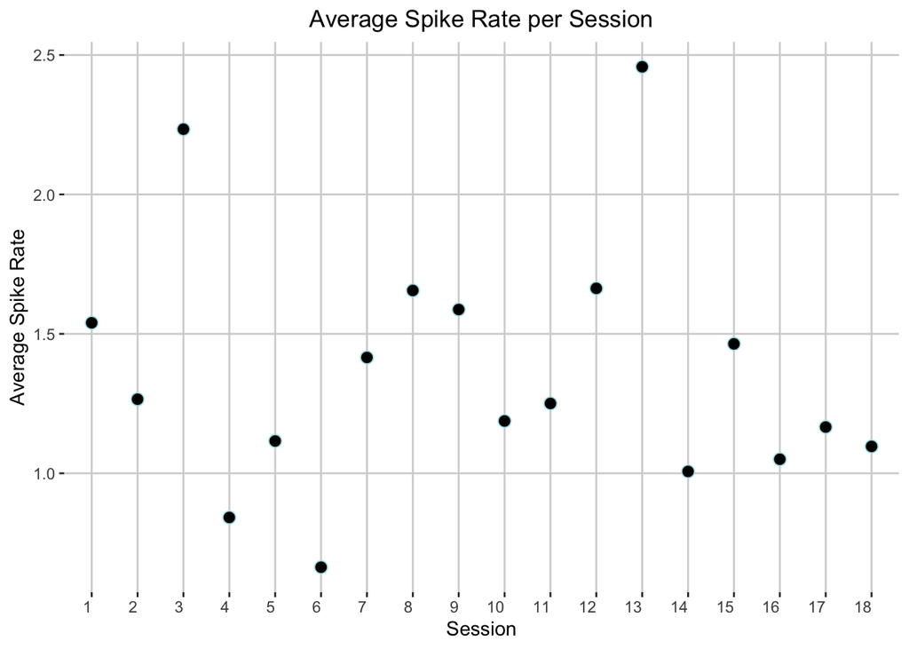

The chart illustrates that the average for each session are not consistent. As the session progresses, there are no significant development of the spike rate. For most of the sessions, it shows and average spike rate in between 1.0 and 2.0.

##### 2-3. Changes Across Trials

Here, I made charts to visualize the overall neuron spike rate change over time. By visualizing the spike rate change over time, I was able to compare experimental conditions over sessions and identify the similarities and differences in neural response under different conditions. The following provides the average spike rate over the number of trials of all 18 sessions.

##### The change of overall neuron spike rate for each session

In the change of overall neuron spike rate for each session, we can see that the majority of average spike rate across sessions show a negative trend. Which means that as number of trials increase, the avarage spike rate seems to decrease. You can see the blue line (the regression line) decrease as trials proceed. Additionally, according to the blue regression line, the average vary a lot throughout the sessions.

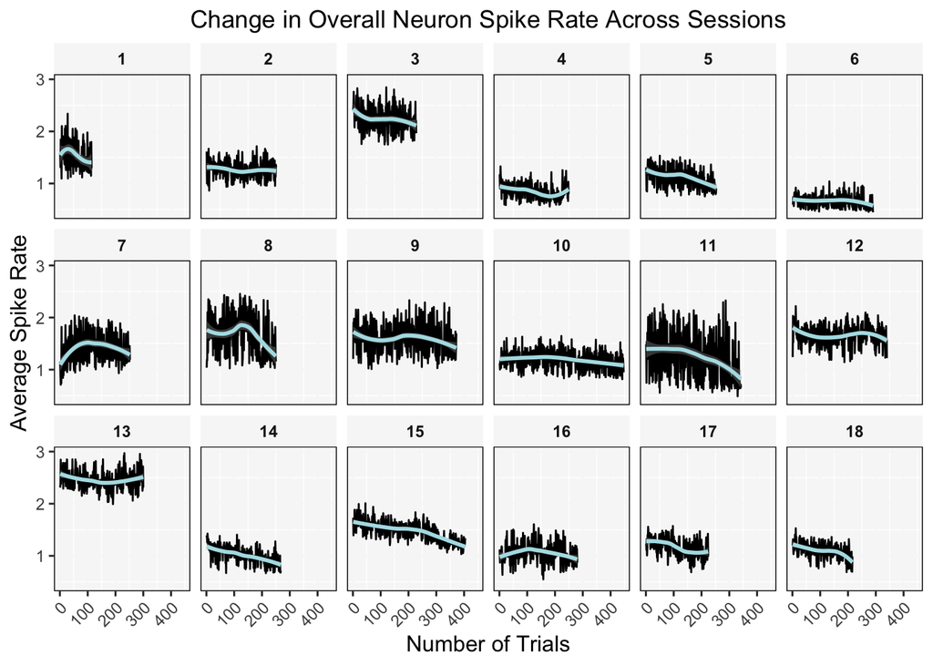

##### The change of overall neuron spike rate for each mouse

I then analyzed the overall neuron spike rate change for each mouse. Neural responses to the same stimuli and experimental conditions can differ among mice. I identified variations in each mouse’s brain activity patterns by examining the variation in spike rates. It also helped me increase the validity of the predictive model I created after the research. Here are the charts :

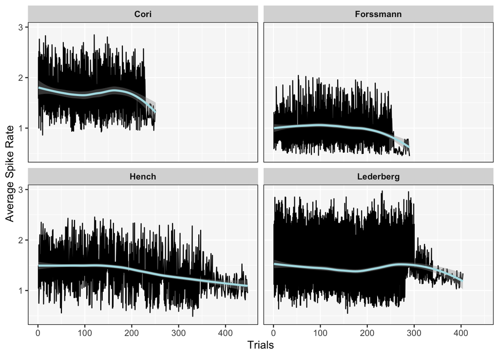

##### 2-4. Homeogeneity and Heterogeneity Across Sessions and Mice

I now address the differences (homeogeneity and heterogeneity) across sessions. But first, I would like to project the estimated success rate over sessions and mouse:

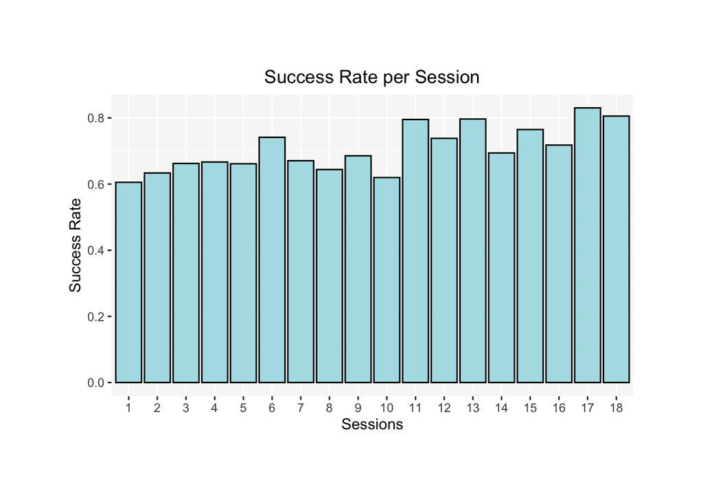

Although not significant difference, above bar chart shows that there is a slight trend of increasing as sessions proceed.

I observed the success rate change over time for individual sessions:

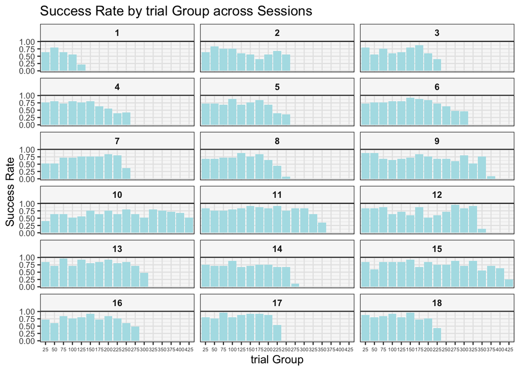

Here, please note that each bar includes 25 trial groups. It seems that there is no consistent trend among success rate over trial groups. Most importantly, we shoule neglect the last bar of every chart since it is not portraying total 25 trials.

Finally, I looked into the success rate change over time for individual mouse:

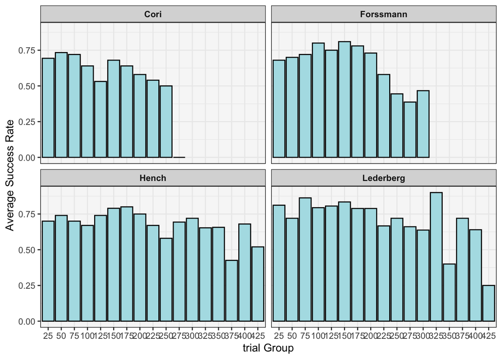

Here again, each bar denotes 25 trials. It seems that the average success rate for Cori, Hench, and Forssmann are having a positive trend in the beginning trial group and a negative trend at the last. For Lederberg, it is projecting an irregular trend.

### | 3. Data Integration |

According to the findings from the data structure, I combined the data across trials by extracting the shared patterns across sessions and addressing the differences between sessions. The goal here was to enable the borrowing of information across sessions to enhance the prediction performance. The table illustrates the names of mice, experiment date, and number of brain areas, neurons, trials, and success rate for each session. Each line indicates one session, so a total of 18 sessions is shown:

Summary of Mice Data

| Names of mouse | Experiment date | Number of brain area | Number of neurons | Number of trials | Success rate |
| --- | --- | --- | --- | --- | --- |
| Cori | 2016-12-14 | 8 | 734 | 114 | 0.61 |
| Cori | 2016-12-17 | 5 | 1070 | 251 | 0.63 |
| Cori | 2016-12-18 | 11 | 619 | 228 | 0.66 |
| Forssmann | 2017-11-01 | 11 | 1769 | 249 | 0.67 |
| Forssmann | 2017-11-02 | 10 | 1077 | 254 | 0.66 |
| Forssmann | 2017-11-04 | 5 | 1169 | 290 | 0.74 |
| Forssmann | 2017-11-05 | 8 | 584 | 252 | 0.67 |
| Hench | 2017-06-15 | 15 | 1157 | 250 | 0.64 |
| Hench | 2017-06-16 | 12 | 788 | 372 | 0.69 |
| Hench | 2017-06-17 | 13 | 1172 | 447 | 0.62 |
| Hench | 2017-06-18 | 6 | 857 | 342 | 0.80 |
| Lederberg | 2017-12-05 | 12 | 698 | 340 | 0.74 |
| Lederberg | 2017-12-06 | 15 | 983 | 300 | 0.80 |
| Lederberg | 2017-12-07 | 10 | 756 | 268 | 0.69 |
| Lederberg | 2017-12-08 | 8 | 743 | 404 | 0.76 |
| Lederberg | 2017-12-09 | 6 | 474 | 280 | 0.72 |
| Lederberg | 2017-12-10 | 6 | 565 | 224 | 0.83 |
| Lederberg | 2017-12-11 | 10 | 1090 | 216 | 0.81 |

### | 4. Predictive Modeling |

The objective of Predictive Modeling section is to build a prediction model to predict outcomes. I aim to find a model that projects high accuracy. In this section, I trained the predictive model on 80% trails and tested on the rest.

##### 4-1. train the model on 80% trials and test it on the rest

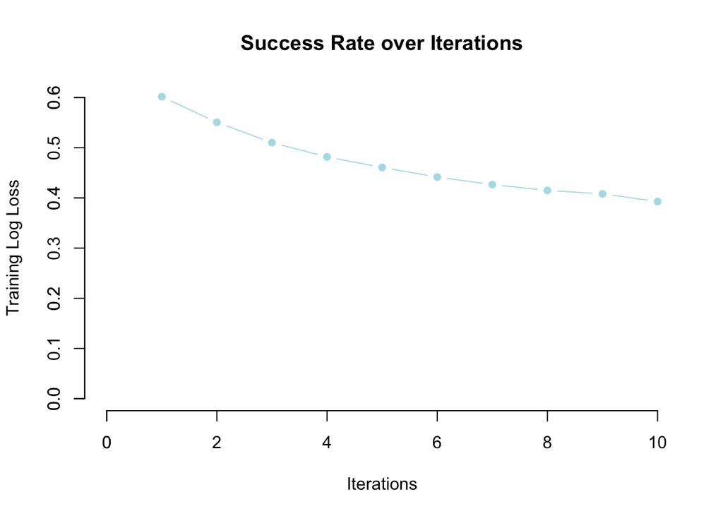

$$\begin{array}{ccc}
\text{Reference} & 0 & 1 \\
\text{Prediction} & & \\
0 & 76 & 52 \\
1 & 221 & 667 \\
\end{array}$$

### | 5. Prediction Performace on the Test Sets |

```
##
## Call:
## roc.default(response = test_label, predictor = predictions)
##
## Data: predictions in 18 controls (test_label 0) > 22 cases (test_label 1).
## Area under the curve: 0.4747
```

### | 7. Reference |

This report reference the following sites:

https://plotly.com/r/ https://chat.openai.com/

- For *https://chat.openai.com/* I had the AI assist with functions of ‘knitr’, ‘kableExtra’, ‘tibble’, ‘ggplot2’, ‘xgboost’, and ‘caret’ package (i.e. designing plots, charts, tables)
- Github : https://github.com/seongeun944/STA141A_Final_Project.git